# Victoria Writeup

## Complete Buyer Data Models

### Pre-crash Models: Linear Regression

We begun by conducting a complete analysis on all the predictors in order to identify the importance of each predictor in determining the price of the house. The result of this analysis will give insight into the weight of each predictor to first time home buyers. Having this information will allow first time home buyers the ability to analyze what is important to them as well as how important certain features are.

Our first model is a linear regression model with the entire training dataset of homes sold within the years 2006 and 2007. We begun this analysis by removing sparse variables such as Ultitilies (All public ultities: 558; Electricity and Gas Only: 0) and Street (Paved: 588; Gravel:0). We then created a correlation plot to discover which (if any) variables were correlated enough to negatively impact our linear regression model. We saw evidence of high correlations between some variables, but only chose to remove the year the garage was built, which was highly correlated with the year the house was built. A Box Cox transformation of our linear regression model urged us to consider $log$(SalePrice) instead of SalePrice as our outcome variable, which we did. Finally, we began to apply linear regression models to the dataset, removing highly correlated factors along the way. Below are the results of our final model.

```
## [1] "A table of the number of important predictors by p-value"
```

```
##                      P-value < 0.001 0.001 <= P-value < 0.01
## Number of predictors              17                      12
##                      0.01 <= P-value < 0.05
## Number of predictors                     19
```

```
## [1] "A tale of the important predictors by p-value"
```

```
##        P-value < 0.001 0.001 <= P-value < 0.01 0.01 <= P-value < 0.05
## 1            X2ndFlrSF      NeighborhoodSawyer          OverallQual10
## 2            X1stFlrSF              BsmtFinSF1           OverallQual8
## 3              LotArea          Condition1PosN    NeighborhoodClearCr
## 4         LandSlopeSev     NeighborhoodGilbert             BsmtFinSF2
## 5  NeighborhoodMeadowV            OverallQual9    NeighborhoodNridgHt
## 6          (Intercept)     NeighborhoodSawyerW    NeighborhoodNoRidge
## 7  NeighborhoodEdwards            OverallCond5     NeighborhoodBrDale
## 8  NeighborhoodMitchel            YearRemodAdd        BsmtFinType1LwQ
## 9         OverallCond7      NeighborhoodTimber    NeighborhoodNPkVill
## 10  NeighborhoodNWAmes               Alleynone           MSSubClass80
## 11   NeighborhoodNAmes             CentralAirY            OpenPorchSF
## 12 NeighborhoodOldTown          BsmtExposureNo    NeighborhoodVeenker
## 13 NeighborhoodCollgCr                                      AlleyPave
## 14        OverallCond9                                 Condition1PosA
## 15        OverallCond8                                     BsmtCondTA
## 16      Condition1Norm                                   MSSubClass50
## 17        OverallCond6                                  MSSubClass160
## 18                                                       MSSubClass60
## 19                                                        PavedDriveY
```

## Complete Buyer Data Models

### Pre-crash Models: Random Forest

We ran a random forest on four-fifths of the dataset choosing random values for the number of trees, number of predictors sampled as candidates at each split, and node size; we chose 120, 22, and 50, respectively. We then tuned these parameters by creating several random forests and taking note of their root mean square error while varying through each parameter separately. The original tree had a RMSE of 36,782.31, while the latter tree had a RMSE of 25,997.13. We found that the most important predictors of house price are: overall quality of the house, square foot of the above ground living area, neighborhood, and the total square feet of the basement.

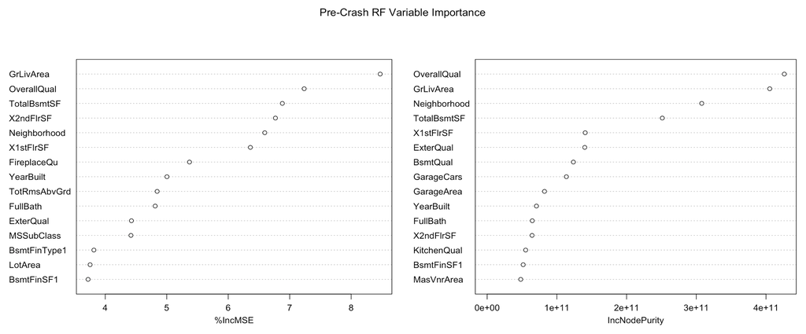

## Complete Buyer Data Models

### Post-crash Models: Linear Regression

We attempted to apply a linear regression model as we did for the Pre-crash Models to the dataset consisting of homes sold within the years 2008, 2009, and 2010. However, the multicollinearlity of the dataset restricted to ``post-crash" dates was too high to be able to do so. Thus, we focused on using a random forest in order to determine the important variables for this dataset.

## Complete Buyer Data Models

### Post-crash Models: Random Forest

We ran a random forest on four-fifths of the dataset choosing random values for the number of trees, number of predictors sampled as candidates at each split, and node size; we chose 120, 22, and 50, respectively. We then tuned these parameters by creating several random forests and taking note of their root mean square error while varying through each parameter separately. The original tree had a RMSE of 38,437.56, while the latter tree had a RMSE of 34,541.53. We found that the most important predictors of house price are: overall quality of the house, square foot of the above ground living area, size of garage in car capacity, neighborhood, and the area of the garage.

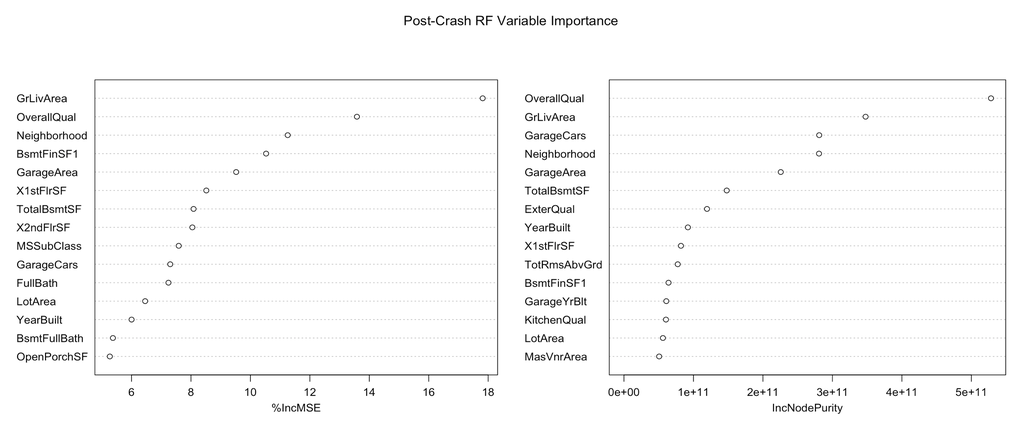

## Complete Buyer Data Models

### Complete Model: Random Forest

We ran a random forest on four-fifths of the dataset choosing random values for the number of trees, number of predictors sampled as candidates at each split, and node size; we chose 120, 22, and 50, respectively. We then tuned these parameters by creating several random forests and taking note of their root mean square error while varying through each parameter separately. The original tree had a RMSE of 33,715.23, while the latter tree had a RMSE of 22,724. We found that the most important predictors of house price are: overall quality of the house, size of garage in car capacity, square foot of the above ground living area, and neighborhood.

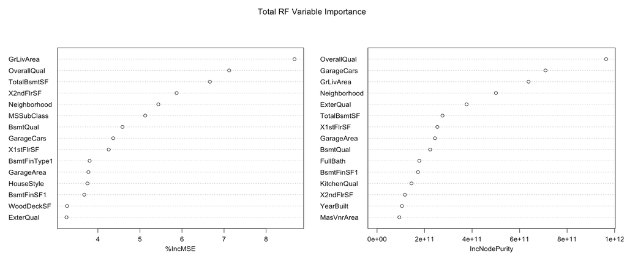

## Complete Buyer Data Models

### Discussion

Another interesting detail is how the important predictors of house prices changed (and didn’t) in our random forest models. We provide a summary of this in the form of a table below.

```
##                                     Pre-Crash
## 1                Overall quality of the house
## 2 Square foot of the above ground living area
## 3                                Neighborhood
## 4           Total square feet of the basement
## 5
##                                    Post-Crash
## 1                Overall quality of the house
## 2 Square foot of the above ground living area
## 3              Size of garage in car capacity
## 4                                Neighborhood
## 5                          Area of the garage
##                                      Complete
## 1                Overall quality of the house
## 2              Size of garage in car capacity
## 3 Square foot of the above ground living area
## 4                                Neighborhood
## 5
```

It was odd that we found an increase of the importance of the size of the garage in terms of car capacity after the crash. Moreover, it is interesting that we found that the best model for price prediction using random forests on all the available predictors was when we did not split the data into before and after the Housing Crisis in 2008. We provide a table summarizing the root mean squared errors of our predictions below.

```r
# RMSE
labels <- c("Pre-Crash", "Post-Crash", "Complete")

df <- data.frame(25,997.13, 34,541.53, 22,724)
colnames(df) <- labels
rownames(df) <- c("RMSE")

df
```

[output not shown]